# Homework 4

# Task A

## Dataset

I used a churn dataset for this task - the same one as in Homework 1. It is a dataset relating characteristics of telephony account features and usage and whether or not the customer churned.

## 1. Select model - random forest

## 2. and 3. Select two observations and calculate variables attributions

I selected observations 1 and 15 as they have different target values. Decompositions of predictions for these variables can be seen below (created with both packages).

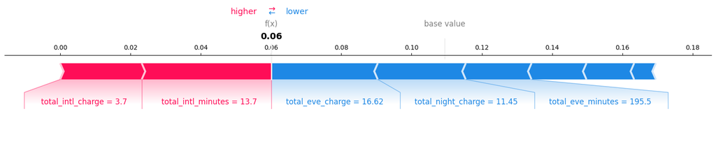

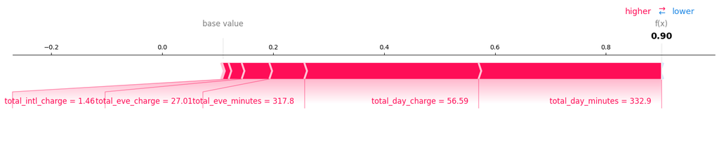

## 4. Observations with different variables of the highest importance

Observations with this property have indices 10 and 12. The highest importance variables for the first one are total_day_minutes and total_day_charge. For the second observation they are total_eve_minutes and total_eve_charge. It is worth noting that the target variable has opposite values for these observations - accordingly 1 and 0. Decompositions can be seen below.

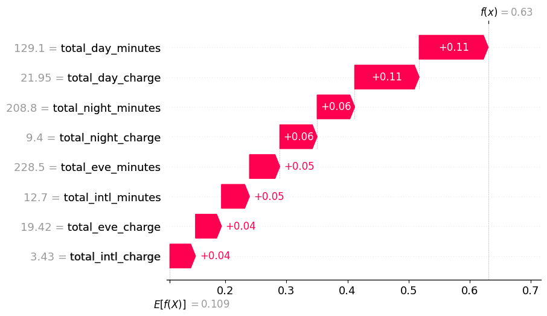

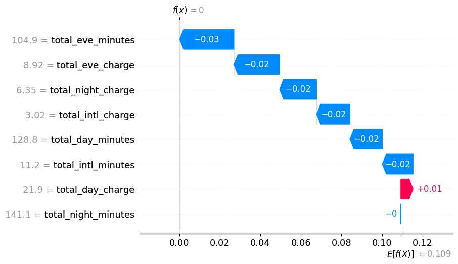

## 5. Opposite attribution of a variable

We can once again use variables 1 and 15 for this task (their decompositions can already be found in point 2 and 3). We can see that total_day_charge and total_eve_minutes have opposite attributions for selected observations.

## 6. Comparison of dalex and shap packages

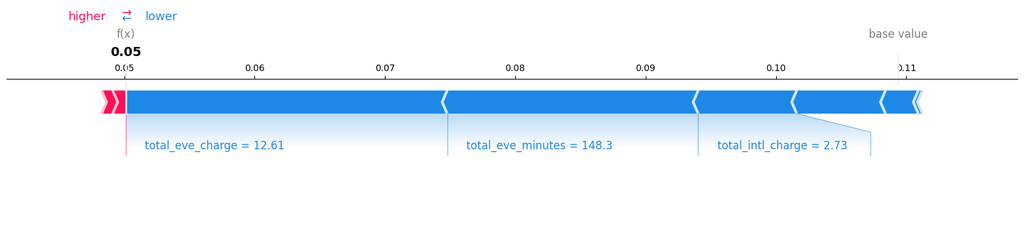

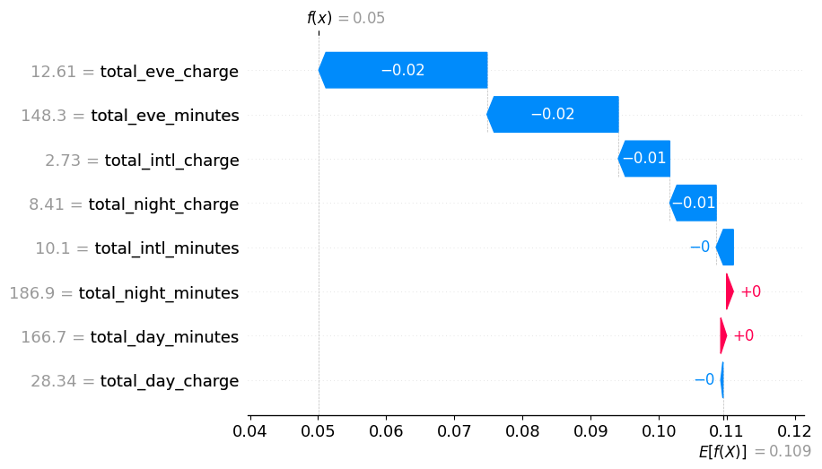

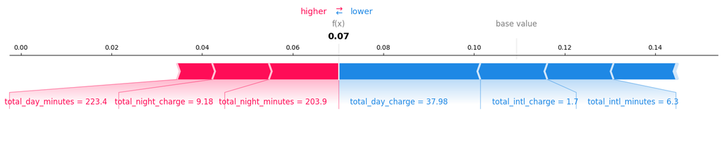

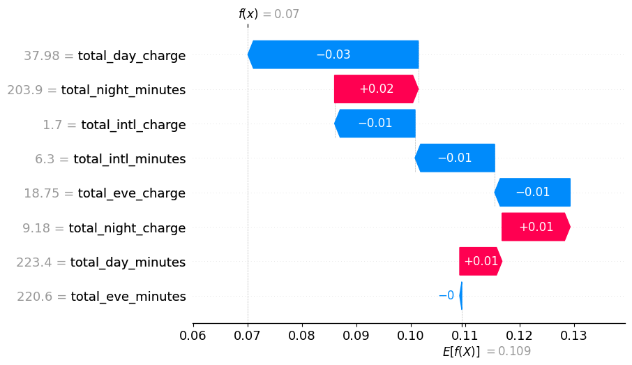

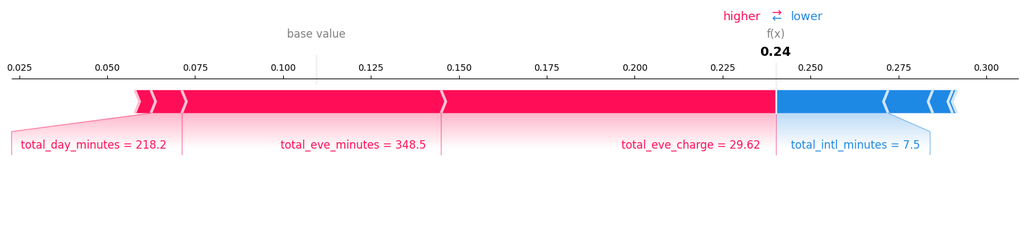

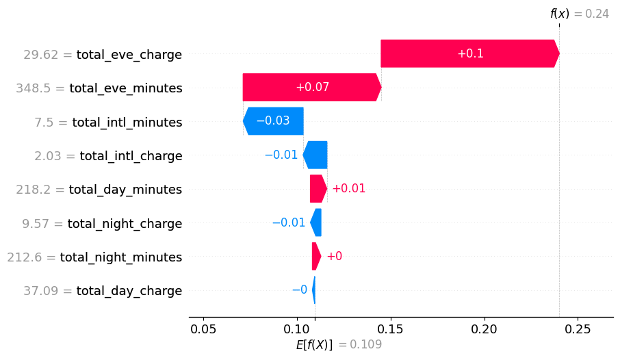

## 7. Models comparison - random forest and decision tree classifier

I selected decision tree classifier as the second model for this comparison. Below there are plotted decompositions of prediction for observation 9. This time differences are easy to spot. Variables total_day_minutes and total_day_charge have positive attributions in predictions produced by both models. However, in case of a decision tree the main variable is total_night_minutes (and its attribution is strongly negative) whereas for a random forest this feature has minor positive impact. Also total_eve_minutes is a strong negative attribute for the decision tree but is nearly irrelevant for the forest.

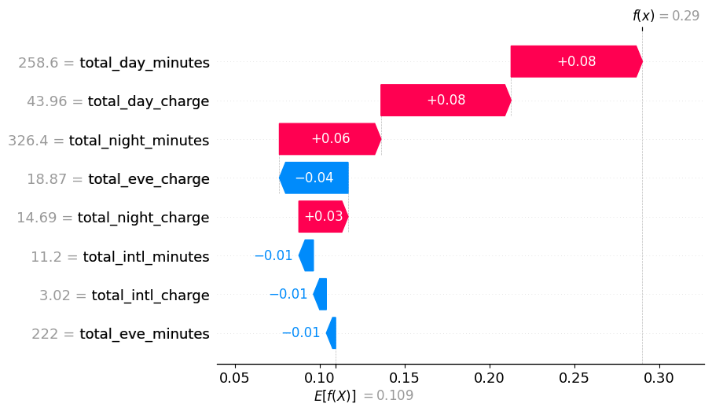

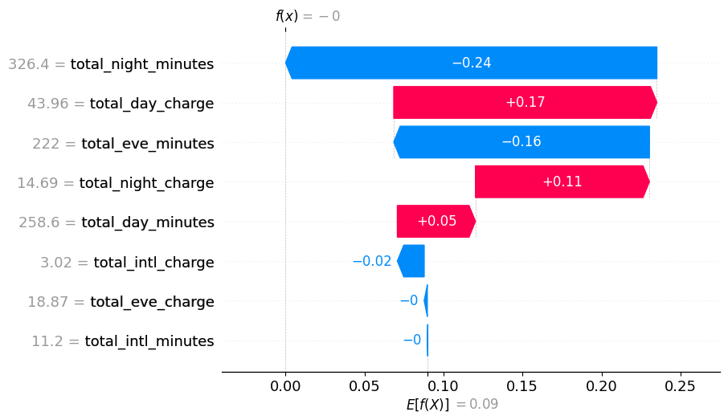

# Task B

v() = 0 v(A) = 20 v(B) = 20 v(C) = 60 v(A,B) = 60 v(A,C) = 70 v(B,C) = 70 v(A,B,C) = 100

[output not shown]

# Appendix

```python
import pandas as pd
import matplotlib.pyplot as plt
import dalex as dx
import shap
```

```python
data = pd.read_csv("datasets/churn.csv", index_col=0)
print(f'Dataset has {data.shape[0]} rows and {data.shape[1]} columns')
display(data.head())
```

```
Dataset has 5000 rows and 9 columns
```

|  | total_day_minutes | total_day_charge | total_eve_minutes | total_eve_charge | total_night_minutes | total_night_charge | total_intl_minutes | total_intl_charge | TARGET |
| --- | --- | --- | --- | --- | --- | --- | --- | --- | --- |
| 0 | 265.1 | 45.07 | 197.4 | 16.78 | 244.7 | 11.01 | 10.0 | 2.70 | 0 |
| 1 | 161.6 | 27.47 | 195.5 | 16.62 | 254.4 | 11.45 | 13.7 | 3.70 | 0 |
| 2 | 243.4 | 41.38 | 121.2 | 10.30 | 162.6 | 7.32 | 12.2 | 3.29 | 0 |
| 3 | 299.4 | 50.90 | 61.9 | 5.26 | 196.9 | 8.86 | 6.6 | 1.78 | 0 |
| 4 | 166.7 | 28.34 | 148.3 | 12.61 | 186.9 | 8.41 | 10.1 | 2.73 | 0 |

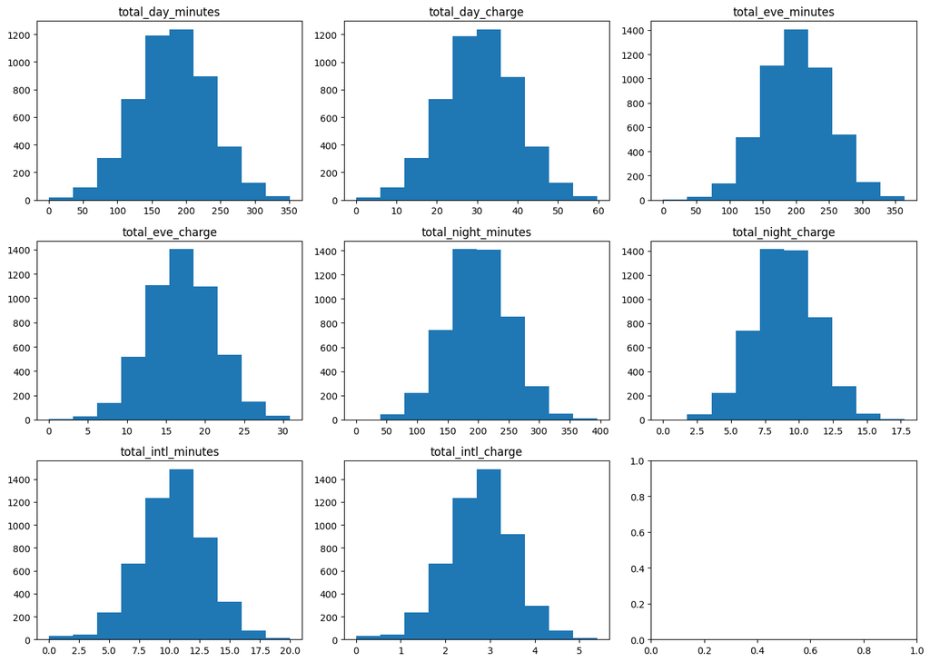

```python
fig, ax = plt.subplots(3, 3, figsize=(14, 10))
for i in range(8):
    ax[i // 3, i % 3].hist(data.iloc[:, i])
    ax[i // 3, i % 3].set_title(data.iloc[:, i].name)

fig.tight_layout()
```

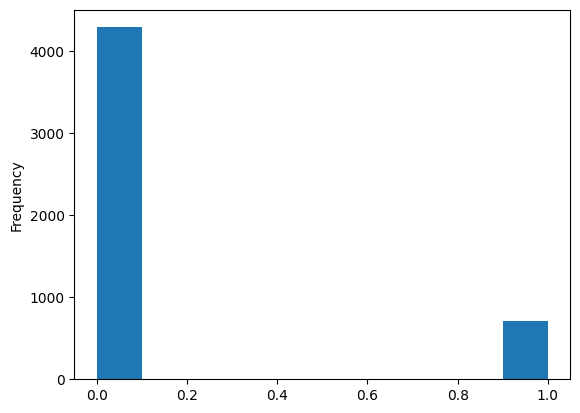

```python
data['TARGET'].plot(kind='hist')
```

## 1. Train random forest model

```python
from sklearn.ensemble import RandomForestClassifier

x, y = data.iloc[:, :-1], data.iloc[:, -1]
random_forest = RandomForestClassifier().fit(x, y)
```

## 2. Select two observations and predict

```python
selected_indices = [1, 15]
display(y.sort_index().iloc[selected_indices])
selected_x = x.sort_index().iloc[selected_indices]
display(selected_x)

random_forest.predict(selected_x)
```

```
1     0
15    1
Name: TARGET, dtype: int64
```

|  | total_day_minutes | total_day_charge | total_eve_minutes | total_eve_charge | total_night_minutes | total_night_charge | total_intl_minutes | total_intl_charge |
| --- | --- | --- | --- | --- | --- | --- | --- | --- |
| 1 | 161.6 | 27.47 | 195.5 | 16.62 | 254.4 | 11.45 | 13.7 | 3.70 |
| 15 | 332.9 | 56.59 | 317.8 | 27.01 | 160.6 | 7.23 | 5.4 | 1.46 |

```
array([0, 1])
```

## 3. Explain with SHAP

```python
shap_explainer = shap.explainers.Tree(random_forest, data=x, model_output="probability")
shap_values = shap_explainer(selected_x)
shap_values
```

```
.values =
array([[[ 0.00617488, -0.00617488],
        [ 0.01357202, -0.01357202],
        [ 0.01871821, -0.01871821],
        [ 0.03027417, -0.03027417],
        [ 0.01563393, -0.01563393],
        [ 0.02504583, -0.02504583],
        [-0.03690869,  0.03690869],
        [-0.02321036,  0.02321036]],

       [[-0.32975773,  0.32975773],
        [-0.31406321,  0.31406321],
        [-0.06299274,  0.06299274],
        [-0.04987012,  0.04987012],
        [ 0.00313464, -0.00313464],
        [-0.00183869,  0.00183869],
        [-0.01174821,  0.01174821],
        [-0.02356393,  0.02356393]]])

.base_values =
array([[0.8906, 0.1094],
       [0.8906, 0.1094]])

.data =
array([[161.6 ,  27.47, 195.5 ,  16.62, 254.4 ,  11.45,  13.7 ,   3.7 ],
       [332.9 ,  56.59, 317.8 ,  27.01, 160.6 ,   7.23,   5.4 ,   1.46]])
```

```python
exp_random_forest = dx.Explainer(random_forest, x, label="random_forest", verbose=False)
```

```python
for i in range(2):
    # Select explanation for probability of churning. Index 0 is for probability of staying.
    shap.plots.waterfall(shap_values[i, :, 1])
```

[output not shown]

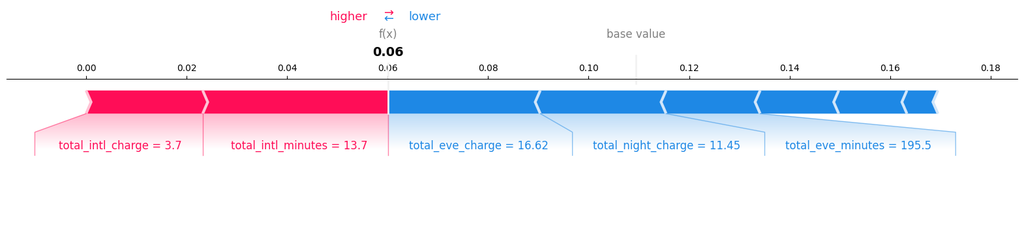

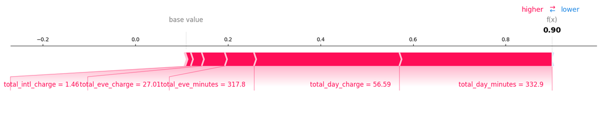

```python
for i in range(2):
    exp_random_forest.predict_parts(selected_x.iloc[[i]], type="shap_wrapper").plot()
```

## 4. Find two observations with different highest importance variables

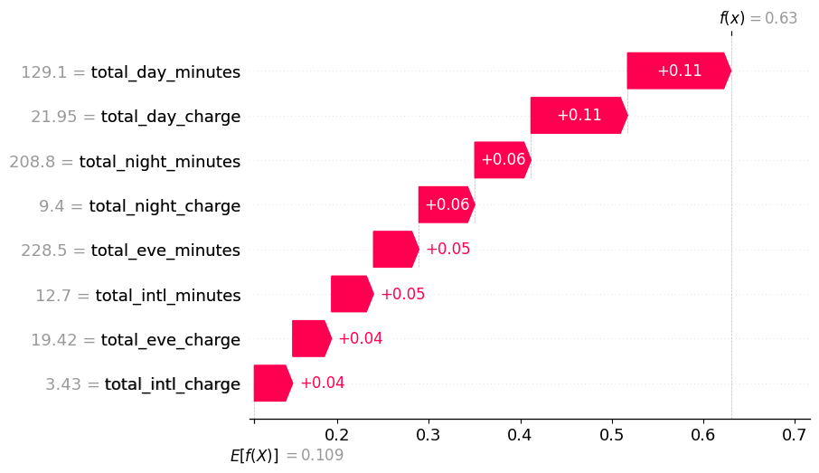

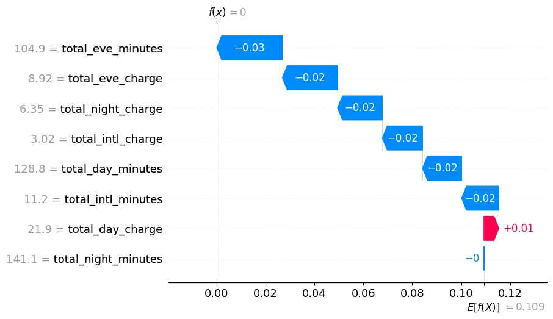

```python
selected_x = x.sort_index().iloc[[10, 12]]
shap_values = shap_explainer(selected_x)

for i in range(2):
    shap.plots.waterfall(shap_values[i, :, 1])
```

## 5. Find observations showing opposite attribution of variable

```python
shap_values = shap_explainer(x.sort_index().iloc[[1, 15]])

for i in range(2):
    shap.plots.waterfall(shap_values[i, :, 1])
```

[output not shown]

## 6. Compare shap and dalex packages

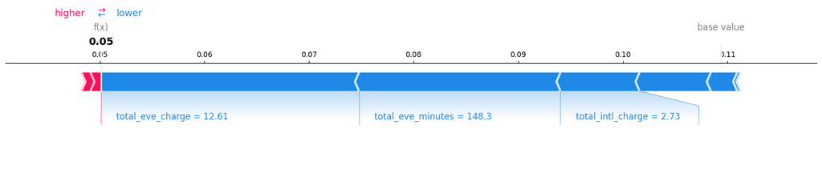

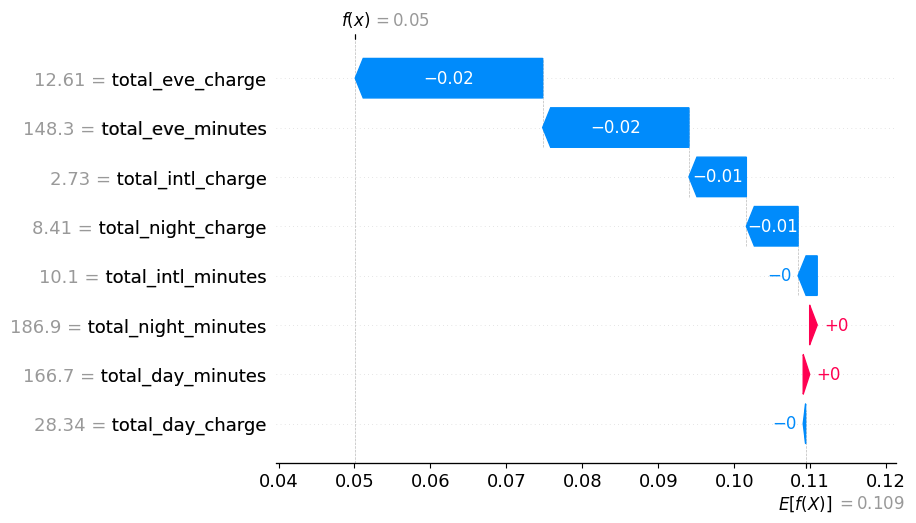

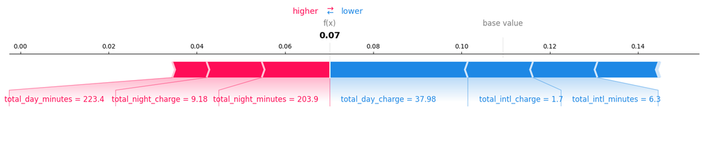

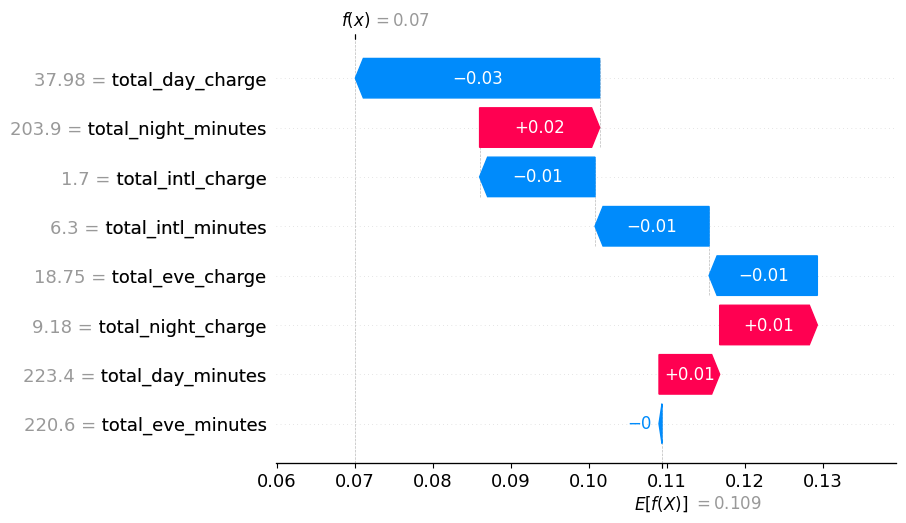

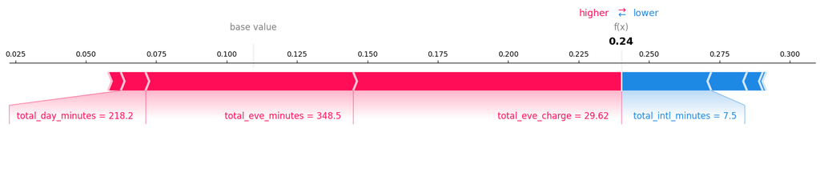

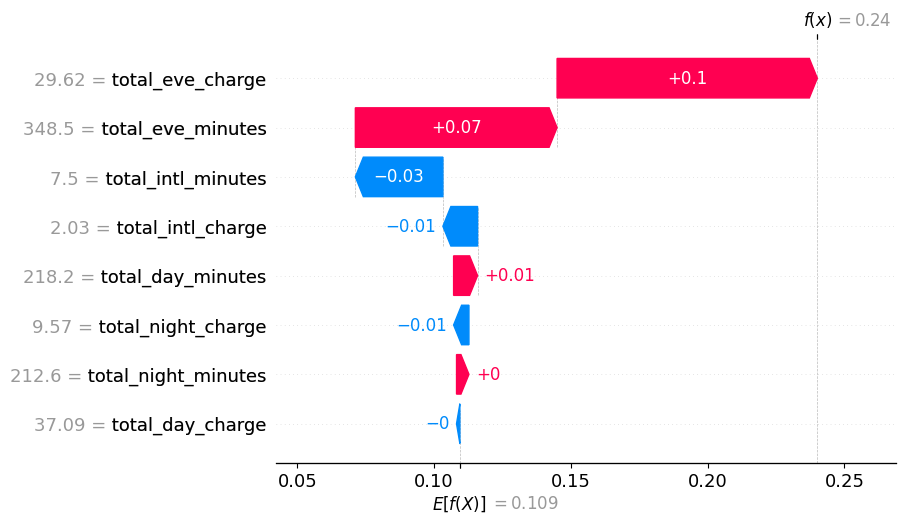

```python
selected_indices = [4, 5, 6]
selected_x = x.sort_index().iloc[selected_indices]
shap_values = shap_explainer(selected_x)

for i in range(3):
    exp_random_forest.predict_parts(selected_x.iloc[[i]], type="shap_wrapper").plot()
    shap.plots.waterfall(shap_values[i, :, 1])
```

## 7. Compare with other model

```python
from sklearn.tree import DecisionTreeClassifier

decision_tree = DecisionTreeClassifier().fit(x, y)
```

```python
selected_x = x.sort_index().iloc[[9]]

shap_explainer_forest = shap.explainers.Tree(random_forest, data=x, model_output="probability")
shap_values_forest = shap_explainer_forest(selected_x)

shap_explainer_tree = shap.explainers.Tree(decision_tree, data=x, model_output="probability")
shap_values_tree = shap_explainer_tree(selected_x)
```

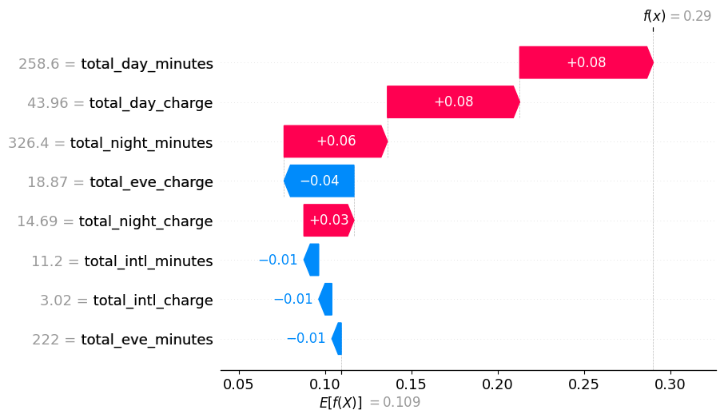

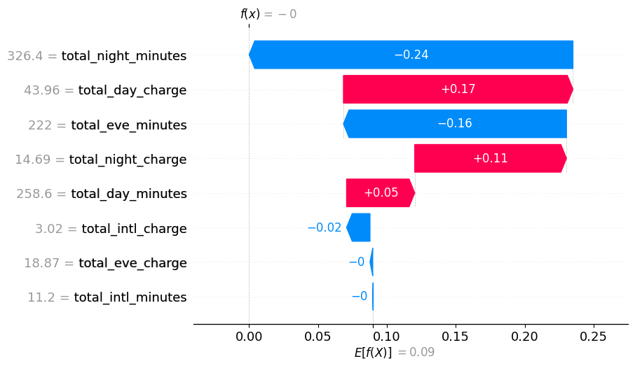

```python
shap.plots.waterfall(shap_values_forest[0, :, 1])
shap.plots.waterfall(shap_values_tree[0, :, 1])
```